# hw5

Steve Simon

May 27, 2018

This program uses R to answer the homework questions to module 5.

```r
library(broom)
library(dplyr)
```

```r
library(ggplot2)
library(magrittr)
library(survival)
library(tidyr)
```

Open the WHAS500 data set in the software program of your choice.

```r
fn <- "~/survival-models/bin/whas500.RData"
load(fn)
head(whas500)
```

```
##   id age gender hr sysbp diasbp      bmi cvd afb sho chf av3     miord
## 1  1  83   Male 89   152     78 25.54051 Yes Yes  No  No  No Recurrent
## 2  2  49   Male 84   120     60 24.02398 Yes  No  No  No  No     First
## 3  3  70 Female 83   147     88 22.14290  No  No  No  No  No     First
## 4  4  70   Male 65   123     76 26.63187 Yes  No  No Yes  No     First
## 5  5  70   Male 63   135     85 24.41255 Yes  No  No  No  No     First
## 6  6  70   Male 76    83     54 23.24236 Yes  No  No  No Yes     First
##       mitype year  admitdate    disdate      fdate los dstat lenfol fstat
## 1 non Q-wave 1997 1997-01-13 1997-01-18 2002-12-31   5 Alive   2178 Alive
## 2     Q-wave 1997 1997-01-19 1997-01-24 2002-12-31   5 Alive   2172 Alive
## 3     Q-wave 1997 1997-01-01 1997-01-06 2002-12-31   5 Alive   2190 Alive
## 4     Q-wave 1997 1997-02-17 1997-02-27 1997-12-11  10 Alive    297  Dead
## 5     Q-wave 1997 1997-03-01 1997-03-07 2002-12-31   6 Alive   2131 Alive
## 6 non Q-wave 1997 1997-03-11 1997-03-12 1997-03-12   1  Dead      1  Dead
##      time_yrs
## 1 5.963039014
## 2 5.946611910
## 3 5.995893224
## 4 0.813141684
## 5 5.834360027
## 6 0.002737851
```

Calculate and graph on the same graph an overall Kaplan-Meier survival curve, a survival curve for an exponential model with no independent variables, and a survival curve for a Weibull model with no independent variables.

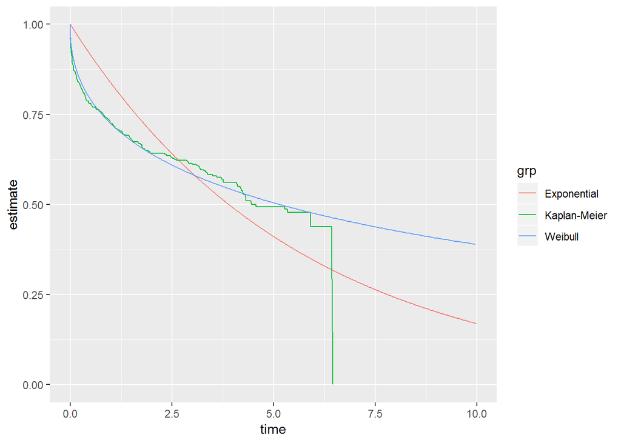

```r
whas500_surv <- Surv(whas500$time_yrs, whas500$fstat=="Dead")
km_overall <- survfit(whas500_surv~1)

exp_null_model <- survreg(whas500_surv~1, dist="exponential")
pct <- (1:999)/1000
exp_null_model %>%
  predict(
    newdata=data.frame(one=1),
    type="quantile",
    p=pct)                     %>%
  data.frame                   %>%
  set_names("time")            %>%
  mutate(estimate=rev(pct))    %>%
  mutate(grp="Exponential")        %>%
  filter(time<=10)             -> exp_survival
weibull_null_model <- survreg(whas500_surv~1, dist="weibull")
weibull_null_model %>%
  predict(
    newdata=data.frame(one=1),
    type="quantile",
    p=pct)                     %>%
  data.frame                   %>%
  set_names("time")            %>%
  mutate(estimate=rev(pct))    %>%
  mutate(grp="Weibull")        %>%
  filter(time<=10)             -> weibull_survival

km_overall                     %>%
  tidy                         %>%
  mutate(grp="Kaplan-Meier")   %>%
  bind_rows(exp_survival)      %>%
  bind_rows(weibull_survival)  -> combined_survivals

combined_survivals             %>%
  ggplot(aes(time, estimate))   +
    expand_limits(y=0)          +
    geom_step(aes(color=grp))
```

Does there appear to be a difference between the exponential model and the Weibull model? Does either model match the Kaplan-Meier curve?

Answer: The exponential model is a poor fit. It overestimates survival early and underestimates it late. The Weibull model is not perfect, but it matches much more closely.

Calculate a Weibull regression model with bmi, age, gender, and a age by gender interaction. Estimate the impact of a 5 unit change in BMI on the survival percentiles, holding all of the other variables constant.

```r
weibull_full_model <- survreg(
  whas500_surv~bmi + age*gender,
  data=whas500,
  dist="weibull")
summary(weibull_full_model)
```

```
##
## Call:
## survreg(formula = whas500_surv ~ bmi + age * gender, data = whas500,
##     dist = "weibull")
##                    Value Std. Error     z        p
## (Intercept)      10.7383     1.7272  6.22 5.06e-10
## bmi               0.0805     0.0300  2.68 7.30e-03
## age              -0.1437     0.0176 -8.17 2.99e-16
## genderFemale     -5.8783     1.9129 -3.07 2.12e-03
## age:genderFemale  0.0766     0.0243  3.15 1.61e-03
## Log(scale)        0.6761     0.0598 11.30 1.34e-29
##
## Scale= 1.97
##
## Weibull distribution
## Loglik(model)= -407.1   Loglik(intercept only)= -483.8
##  Chisq= 153.49 on 4 degrees of freedom, p= 0
## Number of Newton-Raphson Iterations: 5
## n= 500
```

```r
weibull_full_model          %>%
  tidy                      %>%
  filter(term=="bmi")       %>%
  select(estimate)          %>%
  mutate(hr=exp(estimate))  %>%
  mutate(hr5=hr^5)
```

```
##    estimate       hr      hr5
## 1 0.0805085 1.083838 1.495622
```

Calculate a confidence interval for the scale parameter of the Weibull model.

```r
weibull_full_model                           %>%
  tidy                                       %>%
  filter(term=="Log(scale)")                 %>%
  select(estimate, std.error)                %>%
  mutate(scale=exp(estimate))                %>%
  mutate(lo=exp(estimate-1.96*std.error))    %>%
  mutate(hi=exp(estimate+1.96*std.error))
```

```
##    estimate  std.error    scale       lo      hi
## 1 0.6760665 0.05983861 1.966129 1.748543 2.21079
```

Interpret this interval.

Answer: Since this interval excludes the value of 1, you can conclude that the exponential model is not a good fit for the data.

Save everything for possible later re-use.

```r
save.image("~/survival-models/bin/homework-answers-5.RData")
```